# Reproducible Research Project 1

Chris Croupe

3/28/2020

I used the zoo library in the process of converting the NA values to the mean of their surrounding values

```r
library(zoo)
```

### Submission point #1

Here is the code to get the data for the project

```r
url <- "https://d396qusza40orc.cloudfront.net/repdata%2Fdata%2Factivity.zip"

data_file <- "activity.csv"

## Download and unzip the dataset:
if (!file.exists(data_file)){
        download.file(url, "repdata_data_activity.zip")
 }

if (!file.exists(data_file)) {
        unzip("repdata_data_activity.zip")
}
```

Here is the code to read the required data set into the environment

```r
activity_data <- read.csv(data_file, header = TRUE, sep = ",")
```

### Submission point #2

Here is the code to calculate and view the total number of steps taken each day

I created both a histogram and a bar chart to look at this data - although the bar chart was not specifically required

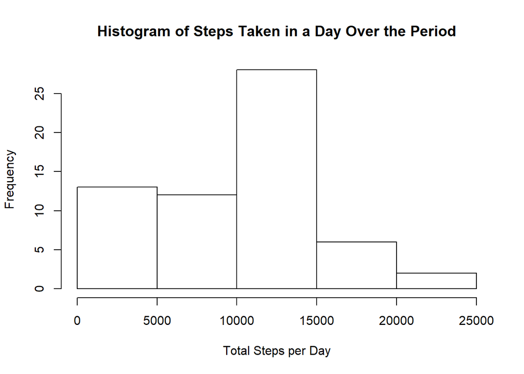

```r
## Get the aggregate number of steps by day
daily_total <- aggregate(activity_data$steps, by=list(activity_data$date), FUN = sum, na.rm = TRUE)
names(daily_total) <- c("date", "steps")

## make a histogram of the daily totals
hist(as.numeric(daily_total$steps), xlab = "Total Steps per Day", main = "Histogram of Steps Taken in a Day Over the Period")
```

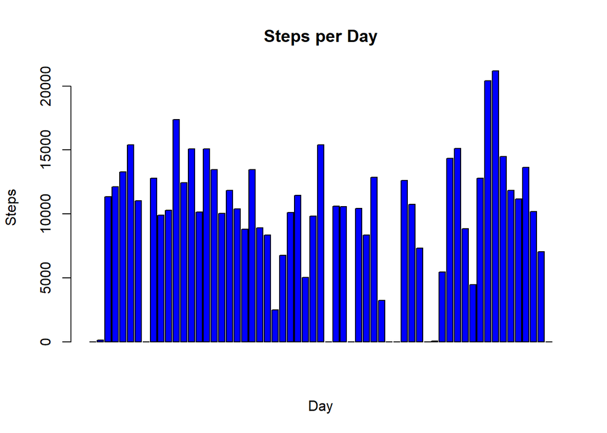

```r
## I'm not sure if the instructions are actually looking for a histogram or a view of the actual steps taken each day
## so I made this as well
barplot(daily_total$steps, ylab = "Steps", xlab = "Day", col = "blue",
        main = "Steps per Day")
```

### Submission point #3

Here is the code to get the mean and median number of steps taken each day

```r
## Get the mean and median number of steps each day - initially I looked at this as the mean number of step per interval
## but the more I look at it the more it seems like the question is asking for the single number mean and median
## number of steps per day across the period of observation - which is available in the call to summary
daily_total <- aggregate(activity_data$steps, by=list(activity_data$date), FUN = sum, na.rm = TRUE)
names(daily_total) <- c("date", "average_steps")
summary(daily_total)
```

```
##          date    average_steps
##  2012-10-01: 1   Min.   :    0
##  2012-10-02: 1   1st Qu.: 6778
##  2012-10-03: 1   Median :10395
##  2012-10-04: 1   Mean   : 9354
##  2012-10-05: 1   3rd Qu.:12811
##  2012-10-06: 1   Max.   :21194
##  (Other)   :55
```

### Submission point #4

Here is the code to plot the time series of avaerage number of steps taken per interval each day

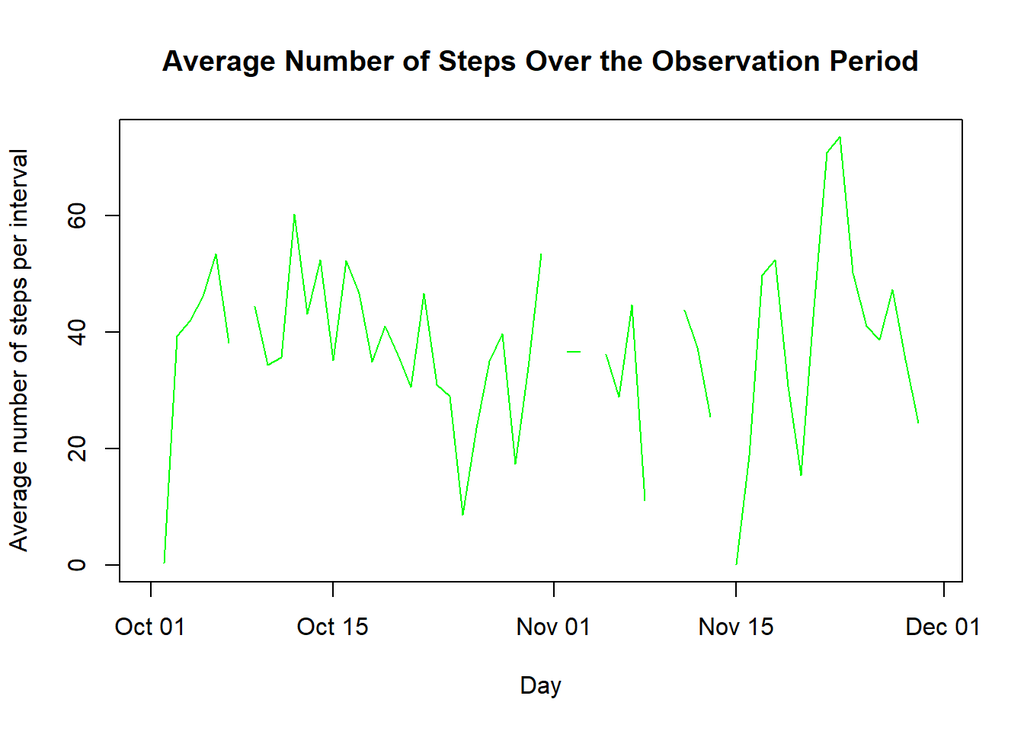

```r
daily_mean <- aggregate(activity_data$steps, by=list(activity_data$date), FUN = mean, na.rm = TRUE)
names(daily_mean) <- c("date", "average_steps")

## Plot the mean steps each day
plot(as.Date(daily_mean$date), daily_mean$average_steps, type = "l", lty = 1,   col = "green",
     xlab = "Day", ylab = "Average number of steps per interval",
     main = "Average Number of Steps Over the Observation Period")
```

### Submission point #5

Here is the code to find the 5-minute interval that, on average, containss the maximum number of steps

```r
## Find the interval that on average, has the maximum number of steps
interval_mean <- aggregate(activity_data$steps, by=list(activity_data$interval), FUN = mean, na.rm=TRUE)
names(interval_mean) <- c("interval", "mean_steps")
max_interval <- interval_mean[which.max(interval_mean$mean_steps),]
max_interval <- max_interval[,1]
max_interval
```

```
## [1] 835
```

### Submission point #6

Here is the code take a look at the NAs and the method to impune the data - I took a simple average of the two data  
observations from the intervals immediately prior to and post the NA observation. I used the na.locf function of the zoo  
library to do this in a simple way.

```r
## How many NAs are there?
count_NAs <- sum (!complete.cases(activity_data))
percent_NAs <- count_NAs/nrow(activity_data)
count_NAs
```

```
## [1] 2304
```

```r
percent_NAs
```

```
## [1] 0.1311475
```

```r
## Find a more elegant way to deal with the NAs
## Using the na.locf function (found on Stack Overflow) - this function does not work if the first or last
## observations are 0 - so I hard set those to 0.

head(activity_data) ## look at activity_data pre-data smoothing
```

```
##   steps       date interval
## 1    NA 2012-10-01        0
## 2    NA 2012-10-01        5
## 3    NA 2012-10-01       10
## 4    NA 2012-10-01       15
## 5    NA 2012-10-01       20
## 6    NA 2012-10-01       25
```

```r
activity_data$steps[1] = 0
activity_data$steps[17568] = 0
activity_data$steps <- (na.locf(activity_data$steps) + rev(na.locf(rev(activity_data$steps))))/2

head(activity_data) ## look at activity_data post-data smoothing
```

```
##   steps       date interval
## 1     0 2012-10-01        0
## 2     0 2012-10-01        5
## 3     0 2012-10-01       10
## 4     0 2012-10-01       15
## 5     0 2012-10-01       20
## 6     0 2012-10-01       25
```

### Submission point #7

Here is the code to re-run the histogram and bar charts from submission point #2 - but this time with the imputed NAs

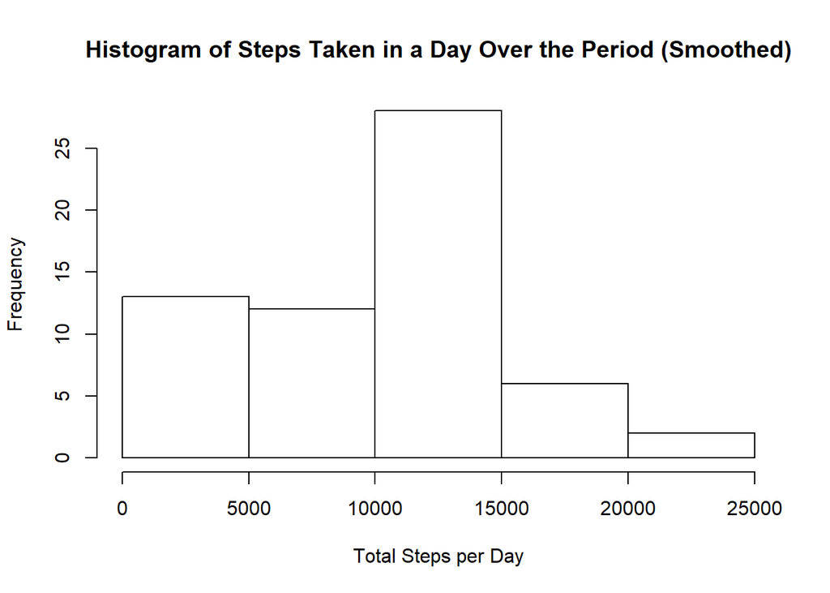

```r
## re-run the histogram and bar plots with the data smoothed

## Get the aggregate number of steps by day
daily_total <- aggregate(activity_data$steps, by=list(activity_data$date), FUN = sum, na.rm = TRUE)
names(daily_total) <- c("date", "steps")

## make a histogram of the daily totals
hist(as.numeric(daily_total$steps), xlab = "Total Steps per Day",
     main = "Histogram of Steps Taken in a Day Over the Period (Smoothed)")
```

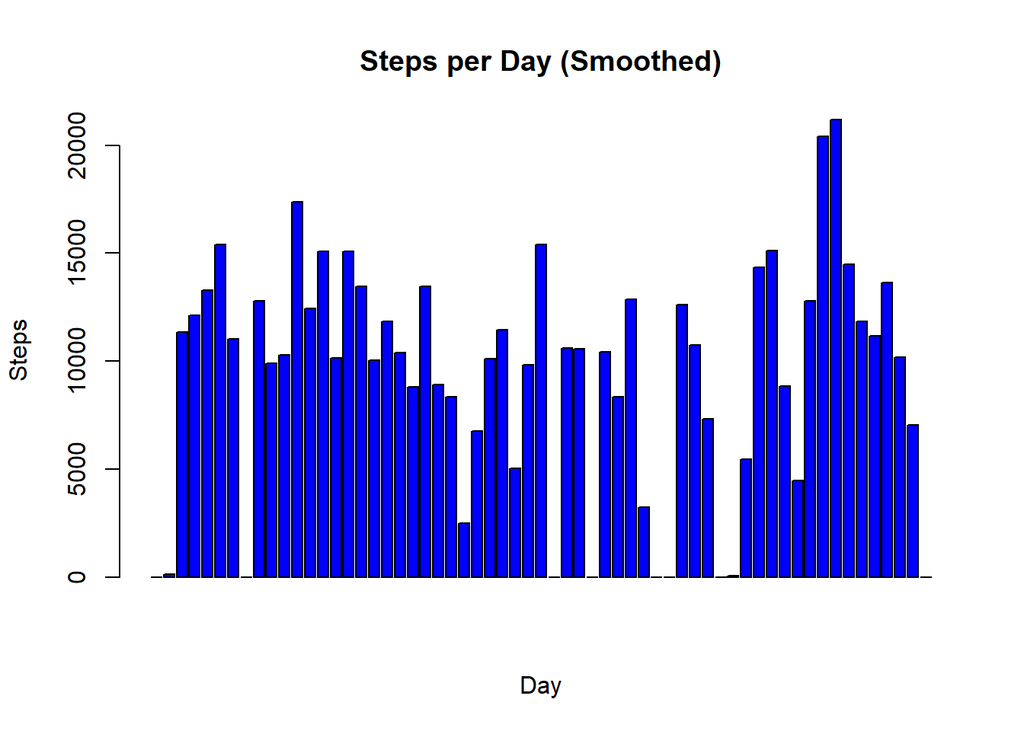

```r
## I'm not sure if the istructions are actually looking for a histogram or a view of the actual steps taken each day
## so I made this as well
barplot(daily_total$steps, ylab = "Steps", xlab = "Day", col = "blue",
        main = "Steps per Day (Smoothed)")
```

### Submission point #8

Here is the code to compare the weekend activity vs. weekdays - I think I did a bit of brute-force coding to break out the weekends for the weekdays and this could be more elegant - but it works

```r
## Compare weekday to weekend steps
## Identify weekdays and weekends
activity_data$Day <- weekdays(as.Date(activity_data$date))
weekend <- c("Saturday", "Sunday")
activity_data$Weekend <- factor(activity_data$Day %in% weekend, levels = c(FALSE, TRUE), labels = c("weekday", "weekend"))

## Get the weekend and weekday interval averages
days_interval_mean <- aggregate(activity_data$steps, by=list(activity_data$Weekend, activity_data$interval),
                                   FUN = mean, na.rm=TRUE)
names(days_interval_mean) <- c("Weekend", "interval", "average_steps")

weekend_interval_mean <- subset(days_interval_mean, Weekend == "weekend")
weekday_interval_mean <- subset(days_interval_mean, Weekend == "weekday")

summary(weekend_interval_mean)
```

```
##     Weekend       interval      average_steps
##  weekday:  0   Min.   :   0.0   Min.   :  0.0000
##  weekend:288   1st Qu.: 588.8   1st Qu.:  0.9688
##                Median :1177.5   Median : 28.0312
##                Mean   :1177.5   Mean   : 37.6936
##                3rd Qu.:1766.2   3rd Qu.: 66.1250
##                Max.   :2355.0   Max.   :153.1250
```

```r
summary(weekday_interval_mean)
```

```
##     Weekend       interval      average_steps
##  weekday:288   Min.   :   0.0   Min.   :  0.000
##  weekend:  0   1st Qu.: 588.8   1st Qu.:  1.922
##                Median :1177.5   Median : 20.778
##                Mean   :1177.5   Mean   : 30.626
##                3rd Qu.:1766.2   3rd Qu.: 44.956
##                Max.   :2355.0   Max.   :202.889
```

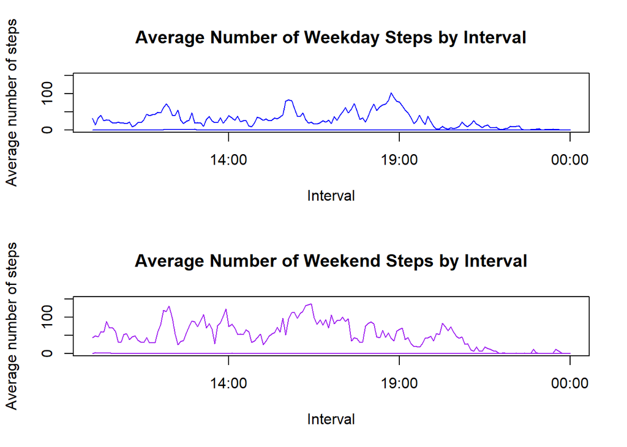

```r
## plot in a couple frames
par(mfrow=c(2,1))

plot(x = strptime(weekday_interval_mean$interval, format("%H%M")), y = weekday_interval_mean$average_steps, type = "l", lty = 1,   col = "blue",
     xlab = "Interval", ylab = "Average number of steps",
     main = "Average Number of Weekday Steps by Interval", ylim = c(0,150))

plot(x = strptime(weekend_interval_mean$interval, format("%H%M")), y = weekend_interval_mean$average_steps, type = "l", lty = 1,   col = "purple",
     xlab = "Interval", ylab = "Average number of steps",
     main = "Average Number of Weekend Steps by Interval", ylim = c(0,150))
```